# Presidents Age Tidy Tuesday

Brandon Brenes

2024-11-25

# Description

# Libraries and Load Data

```r
# library #

library(tidyr)
library(dplyr)
library(here)
library(readr)
library(ggsci)
library(ggplot2)
library(kableExtra)
library(RColorBrewer)
```

```r
# load data from tidy tuesday democracy data #

raw_democracy <- read_csv(here("tidy_tuesday","data", "w13_democracy_data.csv"))

# display #
head(raw_democracy)
```

```
## # A tibble: 6 × 43
##   country_name country_code  year regime_category_index regime_category
##   <chr>        <chr>        <dbl>                 <dbl> <chr>
## 1 Afghanistan  AFG           1950                     5 Royal dictatorship
## 2 Afghanistan  AFG           1951                     5 Royal dictatorship
## 3 Afghanistan  AFG           1952                     5 Royal dictatorship
## 4 Afghanistan  AFG           1953                     5 Royal dictatorship
## 5 Afghanistan  AFG           1954                     5 Royal dictatorship
## 6 Afghanistan  AFG           1955                     5 Royal dictatorship
## # ℹ 38 more variables: is_monarchy <lgl>, is_commonwealth <lgl>,
## #   monarch_name <chr>, monarch_accession_year <dbl>, monarch_birthyear <dbl>,
## #   is_female_monarch <lgl>, is_democracy <lgl>, is_presidential <lgl>,
## #   president_name <chr>, president_accesion_year <dbl>,
## #   president_birthyear <dbl>, is_interim_phase <lgl>,
## #   is_female_president <lgl>, is_colony <lgl>, colony_of <chr>,
## #   colony_administrated_by <chr>, is_communist <lgl>, …
```

# Data manipulation

**Clean up the data**

We are going to select out the columns we need (president_brithdyear, president_accession_year and country_name) then group by country_name.

```r
# clean up raw data #

# select for president birthyear, acccesion year and country #

clean_democracy <- raw_democracy %>% #filter/select out important variables
  select(president_birthyear, president_accesion_year, country_name) %>%
  group_by(country_name) %>%  #group by country
  drop_na() #drop nas

clean_democracy %>%
  head(6) %>%
  kable()
```

| president_birthyear | president_accesion_year | country_name |
| --- | --- | --- |
| 1909 | 1973 | Afghanistan |
| 1909 | 1973 | Afghanistan |
| 1909 | 1973 | Afghanistan |
| 1909 | 1973 | Afghanistan |
| 1917 | 1978 | Afghanistan |
| 1917 | 1978 | Afghanistan |

**Summary data for plot**

We will now make an age column by finding the difference of the two year variables. This will allow us to have a data set we can make an age vs. country box plot

```r
# summary data #

# find the age of the president at the time he/she were elected #

summary_democracy <- clean_democracy %>%
  mutate(president_age = president_accesion_year - president_birthyear) %>%
   # calculate and add the president age
  filter(country_name %in% c("Indonesia", "United States", "France")) %>%
  group_by(country_name) # group by country for plot

# display #
summary_democracy %>%
  head(6) %>%
  kable()
```

| president_birthyear | president_accesion_year | country_name | president_age |
| --- | --- | --- | --- |
| 1884 | 1947 | France | 63 |
| 1884 | 1947 | France | 63 |
| 1884 | 1947 | France | 63 |
| 1884 | 1947 | France | 63 |
| 1882 | 1954 | France | 72 |
| 1882 | 1954 | France | 72 |

**Mean table**

**Calculate mean to visualize data in table format**

```r
# calculate mean to visualize data in table format #

# table mean data peak #
mean_age_by_country <- summary_democracy %>%
  group_by(country_name) %>%
  summarise(mean_age = mean(president_age, na.rm = TRUE))

# display #
mean_age_by_country %>%
  head(6) %>%
  kable()
```

| country_name | mean_age |
| --- | --- |
| France | 60.61972 |
| Indonesia | 48.53521 |
| United States | 57.40845 |

# Plot

Using ggplot and their functions geom_boxplot and geom jitter, I made a boxplot showing the spread and median of president ages in the countries France, United States and Indonesia. I used a scientific color pallete, which I hadn’t heard of before. Very clean and appealing look.

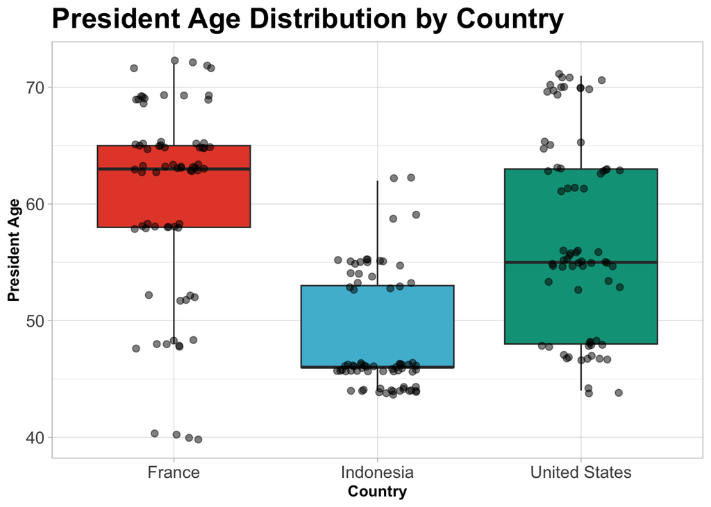

```r
# create the box plot and jittered individual points using ggplot geom_jitter and geom_boxplot #

president_age_box_plot<-ggplot(summary_democracy, aes(x = country_name, y = president_age, fill = country_name)) +
  geom_boxplot(outlier.shape = NA) +  # hide outliers from boxplot
  geom_jitter(width = 0.2, alpha = 0.5, size = 2) +  # add jittered individual points with transparency
  scale_fill_npg() +  #npg pallete
  labs(title = "President Age Distribution by Country",
       x = "Country",
       y = "President Age") +
  theme_light() +  # light theme for the plot
  theme(
    plot.title = element_text(face = "bold", size = 20),  # bold plot title
    axis.title = element_text(face = "bold"),  # bold
    axis.text = element_text(size = 12),  # text size
    legend.position = "none"  # hide legend
  )

president_age_box_plot
```

# What did I learn?

In this week’s *tidy_tuesday*, I learned **a new theme for markdown files** and **a new color pallete**. Both required me to install packages and load libraries, but it was worth it of course. The plot colors are very nice on the eyes, I may use it for my own data sometime soon. The new markdown theme presents the code in a very ‘non-busy’ format. I did want to learn how to make a new plot but was actually really curious as to what these results were going to look like! I will admit that I failed to animate this plot and eventually gave up but will do my research and come back with a good animated plot next week :)